# Machine Learning - Model Validation

*Author:* **Mu Sigma**

*Created:* Sep 30, 2019

# Table of Contents

```python
from IPython.display import HTML

HTML('''<script>
code_show=true;
function code_toggle() {
 if (code_show){
 $('div.input').hide();
 } else {
 $('div.input').show();
 }
 code_show = !code_show
}
$( document ).ready(code_toggle);
</script>
<form action="javascript:code_toggle()"><input type="submit" value="Toggle code - ON/OFF"></form>''')
```

```python
import pandas as pd
import numpy as np

# Visualization packages--
%matplotlib inline
import seaborn as sns
import matplotlib.pyplot as plt

# Silencing the warnings
import warnings
warnings.filterwarnings("ignore")

from sklearn.cluster import KMeans

from yellowbrick.cluster import KElbowVisualizer

from sklearn.cluster import AgglomerativeClustering
import scipy.cluster.hierarchy as sch

from sklearn.metrics import davies_bouldin_score
from sklearn.model_selection import train_test_split
from sklearn.ensemble import RandomForestRegressor
from sklearn.model_selection import cross_val_score

import xgboost as xgb
from sklearn.metrics import mean_squared_error
from sklearn.metrics import f1_score, log_loss, precision_score, recall_score, roc_auc_score, confusion_matrix
from math import sqrt
from sklearn.metrics import jaccard_score

from sklearn import metrics
```

```python
## RoC curve
def roc_curve(test, prediction):
    roc_auc = metrics.roc_auc_score(test, prediction)
    fpr, tpr, thresholds = metrics.roc_curve(test, prediction)
    plt.figure()
    plt.plot(fpr, tpr, label='AuC (area = %0.2f)' % roc_auc)
    plt.plot([0, 1], [0, 1],'r--')
    plt.xlim([-0.05, 1.05])
    plt.ylim([-0.05, 1.05])
    plt.xlabel('False Positive Rate')
    plt.ylabel('True Positive Rate')
    plt.title('Receiver operating characteristic')
    plt.legend(loc="lower right")
    plt.savefig('Log_ROC')
    plt.show()

## Function 4 : Plot confusion Matrix
def plot_confusion_matrix(y_true, y_pred, classes,
                          normalize = False,
                          title = None,
                          cmap=plt.cm.Greens):
    """
    This function prints and plots the confusion matrix.
    Normalization can be applied by setting `normalize=True`.
    """
    if not title:
        if normalize:
            title = 'Normalized confusion matrix'
        else:
            title = 'Confusion matrix, without normalization'

    # Compute confusion matrix
    cm = confusion_matrix(y_true, y_pred)
    if normalize:
        cm = cm.astype('float') / cm.sum(axis=1)[:, np.newaxis]
        print("Normalized confusion matrix")
    else:
        print('Confusion matrix, without normalization')

    print(cm)

    fig, ax = plt.subplots()
    im = ax.imshow(cm, interpolation='nearest', cmap=cmap)
    ax.figure.colorbar(im, ax=ax)
    # We want to show all ticks...
    ax.set(xticks=np.arange(cm.shape[1]),
           yticks=np.arange(cm.shape[0]),
           # ... and label them with the respective list entries
           xticklabels=classes, yticklabels=classes,
           title=title,
           ylabel='True label',
           xlabel='Predicted label')

    # Rotate the tick labels and set their alignment.
    plt.setp(ax.get_xticklabels(), rotation=45, ha="right",
             rotation_mode="anchor")

    # Loop over data dimensions and create text annotations.
    fmt = '.2f' if normalize else 'd'
    thresh = cm.max() / 2.
    for i in range(cm.shape[0]):
        for j in range(cm.shape[1]):
            ax.text(j, i, format(cm[i, j], fmt),
                    ha="center", va="center",
                    color="white" if cm[i, j] > thresh else "black")
    fig.tight_layout()
    return ax
```

## Introduction

### Overview

Model validation is the set of processes and activities intended to verify that models are performing as expected, in line with their design objectives and business uses. Effective validation helps ensure that models are sound. It also identifies potential limitations and assumptions, and assesses their possible impact. It is the process of deciding whether the numerical results quantifying hypothesized relationships between variables, obtained from the model, are acceptable as descriptions of the data.

The validation process can involve:

- Analyzing the goodness of fit of the model
- Analyzing whether the regression residuals are random
- Checking if the model is not overfitting or under fitting the data
- Checking whether the model’s predictive performance does not deteriorate substantially when applied to data that were not used in model estimation

### Objective

Model validation has two objectives:

- **Model selection:** estimating the performance of different models in order to choose the best one
- **Model assessment:** having chosen a final model, estimating its prediction error (generalization error) on new data

### Why is Model Validation required?

Model Validation is required for the following reasons:

- **Generalization:** The generalization performance of a learning method relates to its prediction capability on independent test data. Assessment of this performance is extremely important in practice, since it guides the choice of learning method or model, and gives us a measure of the quality of the ultimately chosen model. Model validation is used for performance assessment of different models and choose the best fitting model.
- **Overfitting:** If a learning technique learns the structure of a training data too well, if the model is applied to the data on which the model was built, it will correctly predict every sample value. In the extreme case, the model in training data admits no error. In addition to learning the general patterns in the data, the model has also learned the characteristics of each training data point’s unique noise. This type of model is said to be over-fit and will usually have poor accuracy when predicting a new sample. Model validation is used to detect if a model is overfitting.
- **Optimization of parameter:** Frequently it is desirable to tune some parameters to get the best performance from an algorithm: examples might be the amount of pruning in a decision tree or the number of hidden nodes in the multilayer perceptron. Model validation is used to tune these parameters.

### Bias – Variance trade off

The bias–variance tradeoff is the problem of simultaneously minimizing two sources of error that prevent supervised learning algorithms from generalizing beyond their training set:

- The **bias** is the error from erroneous assumptions in the algorithm. High bias can cause an algorithm to miss the relevant relations between features and target outputs (**underfitting**).
- The **variance** is error from sensitivity to the small fluctuations in the training set. High variance can cause overfitting which is modeling the random noise in the training data, rather than the intended outputs.

Ideally, one wants to choose a model that accurately captures the regularities in its training data, and also generalizes well to unseen data. Unfortunately, it is typically impossible to do both simultaneously. High-variance learning methods may be able to represent their training set well, but are at risk of overfitting to noisy or unrepresentative training data. In contrast, algorithms with high bias typically produce simpler models that don’t tend to overfit, but may underfit their training data, failing to capture important regularities.

Models with low bias are usually more complex (e.g. higher-order regression polynomials), enabling them to represent the training set more accurately. In the process, however, they may also represent a large noise component in the training set, making their predictions less accurate – despite their added complexity. In contrast, models with higher bias tend to be relatively simple (low-order or linear regression polynomials), but may produce lower variance predictions when applied beyond the training set.

*The best learner is the one which can balance the bias and the variance of a model.*

Cross-validation (type of model validation) is a comprehensive set of data splitting techniques which helps to estimate the point of inflexion of Prediction Error.

[figure not shown]

## Common Techniques

This section contains details on common validation techniques which can be used across clustering, classification and regression models. The following five techniques are covered in this module:

1. Holdout
2. Random Subsampling
3. Cross Validation  
   a) K Fold Cross Validation  
   b) Stratified K Fold Cross Validation  
   c) Leave-p-Out Cross Validation (LpO CV)  
   d) Leave-One-Out Cross Validation (LOOCV)
4. Bootstrapping
5. Out of Sample and Out of Time Validation

```python
# Read the data
train = pd.read_csv('Regression.csv')
```

### Holdout

If we are in a data-rich situation, the best approach is to randomly divide the dataset into three parts: a training set, a validation set, and a test set. The training set is used to fit the models; the validation set is used to estimate prediction error for model selection; the test set is used for assessment of the generalization error of the final chosen model. Ideally, the test set should be kept in a “vault,” and be brought out only at the end of the data analysis.

[figure not shown]

It is difficult to give a general rule on how to choose the number of observations in each of the three parts, as this depends on the signal-to noise ratio in the data and the training sample size. A typical split might be 50% for training, and 25% each for validation and testing.

A typical application of the holdout method is determining a stopping point for the back propagation error.

[figure not shown]

**The holdout method has two basic drawbacks**:

- In problems where we have a sparse dataset we may not be able to afford the luxury of setting aside a portion of the dataset for testing
- Since it is a single train-and-test experiment, the holdout estimate of error rate will be misleading if we happen to get an unfortunate split

**Methodology**

A typical methodology of holdout validation is given in the below image and the steps of the same are explained below.

[figure not shown]

The explanation of labels in the above figure:

1. Divide the dataset into training, validation and testing data
2. Build a model using training dataset  
   a) Find a subset of “good” predictors that show fairly strong (univariate) correlation with the dependent variable, using all of the samples in training dataset  
   b) Using just this subset of predictors, build a multivariate model, using all of the samples in training. Multiple models using different set of parameters / algorithms can be made  
   c) Finalize a/few model(s) which are giving a good depiction of data
3. Score the model(s) using validation dataset
4. Use the results obtained from last step to tune the parameters and finalize the model
5. Compare the prediction error of validation dataset with the training dataset. Both of these errors should be almost similar so that there is no under/over fitting
6. Finalize a/few model(s) which are giving a good depiction of data
7. Score the above model for testing dataset. Check how the model behaves for unseen data to confirm generalization

**Pros**:

- Very simple
- Usually preferable to the residual method and takes no longer to compute
- Hold-out validation avoids the overlap between training data and test data, yielding a more accurate estimate for the generalization performance of the algorithm

**Cons**:

- The disadvantage is that the evaluation may be significantly different depending on how the division is made.
- In problems where we have a sparse dataset we may not be able to afford the “luxury” of setting aside a portion of the dataset for testing
- This procedure does not use all the available data and the results are highly dependent on the choice for the training/test split.

**When to use:** In case of huge datasets

House price prediction dataset is used for the following exercises. The objective is to predict the price of a house, give area, year on which the house was built and other factors which impact the price.

```python
predictor_cols = ['LotArea', 'OverallQual', 'YearBuilt', 'TotRmsAbvGrd']
y = train.SalePrice
X = train.loc[:, train.columns.isin(predictor_cols)]

# pull data into target (y) and predictors (X)
X_train, X_test, y_train, y_test = train_test_split(X, y, test_size=0.5, random_state=101)

X_validation, X_test, y_validation, y_test = train_test_split(X_test, y_test,
                                                              test_size=0.5, random_state=101)
```

Random forest model is used for predicting the house prices. Various validation techniques shall be performed on the model to measure the accuracy.

```python
my_model = RandomForestRegressor()
my_model.fit(X_train, y_train)

y_rf_predictions = my_model.predict(X_test)
y_rf_v_predictions = my_model.predict(X_validation)
```

```python
from sklearn.metrics import mean_squared_error
from math import sqrt
print("RMSE of the Model : {}".format(sqrt(mean_squared_error(y_test, pd.Series(y_rf_predictions)))))
```

```
RMSE of the Model : 39173.46573182035
```

```python
print("RMSE of the Model : ",sqrt(mean_squared_error(y_validation, pd.Series(y_rf_v_predictions))))
```

```
RMSE of the Model :  40081.42533407113
```

In the holdout method, as seen above, the difference in RMSE is not comparitively high.

### Random Subsampling

Random subsampling, which is also known as multiple holdout or Monte Carlo crossvalidation or repeated evaluation set, is based on randomly splitting the data into subsets. The random partitioning of the data is **repeated multiple (k) times**. For each data split we retrain the model from scratch with the training samples and estimate error with the validate samples. The final error is the average of separate error estimate. In contrast to a full crossvalidation procedure, random subsampling has been shown to be asymptotically consistent resulting in more pessimistic predictions of the test data compared with crossvalidation. The predictions of the test data give a realistic estimation of the predictions of external validation data.

[figure not shown]

### Cross Validation

#### K Fold Cross Validation

K fold cross validation is one of the most widely used validation technique. Ideally, if we had enough data, we would set aside a validation set and use it to assess the performance of our prediction model. Since data are often scarce, this is usually not possible. To finesse the problem, K-fold crossvalidation uses part of the available data to fit the model, and a different part to test it. We split the data into K roughly equal-sized parts; for example, when K = 5, the scenario looks like this:

[figure not shown]

For the kth part (third above), we fit the model to the other K −1 parts of the data, and calculate the prediction error of the fitted model when predicting the kth part of the data. We do this for k = 1, 2, ….. K and average the K estimates of prediction error.

[figure not shown]

**The advantages of k fold validation are:**

- All observations are used for both training and validation
- Each observation is used for validation exactly once

**Typical choices of K are 5 or 10.**

**Methodology**

1. Divide the samples into K cross-validation folds (groups) at random.
2. For each fold k = 1, 2, . . . ,K  
   a. Find a subset of “good” predictors that show fairly strong (univariate) correlation with the dependent variable, using all of the samples except those in fold k  
   b. Using just this subset of predictors, build a multivariate classifier, using all of the samples except those in fold k  
   c. Use the model to predict the output (score) for the samples in fold k.
3. The error estimates from step B (c) are then accumulated over all K folds, to produce the cross-validation estimate of prediction error

**Pros**:

- The advantage of this method is that it matters less how the data gets divided. All observations are used for both training and validation, and each observation is used for validation exactly once
- One major advantage to K-fold Cross Validation over Leave-One-Out Validation is that it requires considerably less computational resources. Because rather than fitting the statistical model as many times as the number of observations in your data set, you fit it, a substantially smaller number of times, typically less than 20 times

**Cons**:

- The disadvantage of this method is that the training algorithm has to be rerun from scratch *k* times, which means it takes *k* times as much computation to make an evaluation.

**When to use**:For datasets of moderate size

```python
my_model = RandomForestRegressor()
my_model.fit(X, y)
print("Cross Validation Scores: ",cross_val_score(my_model, X, y, cv=4))
```

```
Cross Validation Scores:  [0.79044554 0.74800786 0.73580458 0.73182504]
```

#### Stratified K Fold Cross Validation

In stratified k-fold cross-validation, the folds are selected so that the mean response value is approximately equal in all the folds. In the case of a dichotomous classification, this means that each fold contains roughly the same proportions of the two types of class labels. This is done to make sure that training and validation subset are true depiction of original dataset.

**Pros**:

- The biggest advantage of stratified validation is that it reduces selection bias. Stratifying the entire population before applying random sampling methods helps ensure a sample that accurately reflects the population being studied in terms of the criteria used for stratification

**Cons**:

- The method’s disadvantage is that several conditions must be met for it to be used properly
- Accurately sorting each member of the population into a single stratum is also a challenging task

**When to use**: Used when the target variable has uneven distribution across its classes

```python
import numpy as np
from sklearn.model_selection import StratifiedKFold
X = np.array([[1, 2], [3, 4], [1, 2], [3, 4]])
y = np.array([0, 0, 1, 1])
skf = StratifiedKFold(n_splits=2)
skf.get_n_splits(X, y)
print(skf)
StratifiedKFold(n_splits=2, random_state=None, shuffle=False)
for train_index, test_index in skf.split(X, y):
    print("TRAIN:", train_index, "TEST:", test_index)
    X_train, X_test = X[train_index], X[test_index]
    y_train, y_test = y[train_index], y[test_index]
```

```
StratifiedKFold(n_splits=2, random_state=None, shuffle=False)
TRAIN: [1 3] TEST: [0 2]
TRAIN: [0 2] TEST: [1 3]
```

#### Leave-p-Out Cross Validation (LpO CV)

Leave-p-out cross-validation involves using p observations as the validation set and the remaining observations as the training set. This is repeated on all ways to cut the original sample on a validation set of p observations and a training set. LpO cross-validation requires training and validating the model $C_p^n$ times, where *n* is the number of observations in the original sample. For even moderately large *n*, LpO CV can become computationally infeasible.

```python
from sklearn.model_selection import LeavePOut

X = np.ones(4)
lpo = LeavePOut(p=2)
print("Leave-P-out Cross Validation")
for train, test in lpo.split(X):
    print("%s %s" % (train, test))
```

```
Leave-P-out Cross Validation
[2 3] [0 1]
[1 3] [0 2]
[1 2] [0 3]
[0 3] [1 2]
[0 2] [1 3]
[0 1] [2 3]
```

Since it is computationally expensive, earlier dataset cannot be used for the demo as size of the dataset is not supportive. The above example shows how a typical LpO CV takes place

#### Leave-One-Out Cross Validation (LOOCV)

Leave-one-out cross-validation (LOOCV) is a particular case of leave-p-out cross validation with p = 1 or it is a special case of K fold cross validation with k = n, where n is the number of observation. LOOCV does not have the same problem of excessive compute time as general LpO cross-validation because $C_1^n= n$.

**Advanatages of LOOCV are**:

- The size of training dataset is maximized
- All observations are used for validation exactly once

**Pros**:

- It has the advantages of producing model estimates with less bias and more ease in smaller samples
- Less bias as training-set is of n-1 size. Because of this reduced bias, reduced over-estimation of test-error

**Cons**:

- Computationally expensive (time and power) especially if dataset is big with large n as it requires fitting the model n times
- Even though each iterations test-error is un-biased, it has a high variability as only one-observation was used for prediction

**When to use:** For datasets which are small enough to run n iterations and extremely high accuracy is required</p>

```python
from sklearn.model_selection import LeaveOneOut

X = [1, 2, 3, 4]
loo = LeaveOneOut()
print("Leave-One-Out Cross Validation (LOOCV)")
for train, test in loo.split(X):
    print("%s %s" % (train, test))
```

```
Leave-One-Out Cross Validation (LOOCV)
[1 2 3] [0]
[0 2 3] [1]
[0 1 3] [2]
[0 1 2] [3]
```

Since it is computationally expensive, earlier dataset cannot be used for the demo as size of the dataset is not supportive. The above example shows how a typical LOOCV takes place

### Bootstrapping

Bootstrapping is a resampling technique with replacement. From a dataset with n observations, m observations with replacement are selected and used as training dataset. The remaining observations are used for validation. The above process is repeated k times. The true error is estimated to be average error of test iterations.

**Pros**:

- Bootstrapping is the best error estimator for small datasets
- Compared to basic CV, the bootstrap increases the variance that can occur in each fold
- The bootstrap allows us to estimate bias and variance for practically any statistical estimate

**Cons**:

- In more complex data situations, figuring out the appropriate way to generate bootstrap samples can require some thought

**When to use**:

- Ideally for very small datasets or special or rare datasets
- Generally used when randomness is required

### Out of Sample and Out of Time Validation

In out of sample validation, we use the dataset for validation which is apart from the training dataset. Example – a model which is trained on observations from North America and validated on observations from South America.

Out-of-time validation is just out-of-sample validation on a *later* data-set than that on which you fitted your model; where application of a model to a population changing over time is the concern. Example – a model trained on records from Jan 2016 to Oct 2016 and validated on records from Nov 2016 to Dec 2016.

## Regression Validation

Regression analysis is a statistical process for estimating the relationships among variables. The focus is on the relationship between a dependent variable (criterion variable) and one or more independent variables (predictors). More specifically, regression analysis helps one understand how the typical value of the dependent variable changes when any one of the independent variables is varied, while the other independent variables are held fixed.

Regression validation is the process of deciding whether the numerical results quantifying hypothesized relationships between variables, obtained from regression analysis, are acceptable as descriptions of the data. The validation process can involve

- Analyzing the goodness of fit of the regression
- Analyzing whether the regression residuals are random
- Checking whether the assumptions of modelling algorithm are met

Checking whether the model’s predictive performance deteriorates substantially when applied to data that were not used in model estimation (**model generalization**)

### Regression Validation Methodology

General approach for regression model validation is:

1. Randomly divide the dataset into training and validation samples
2. Apply regression algorithm on the training dataset
3. Use the fitted model to score all records present in validation dataset
4. For both the training and the validation samples, different validation measures are computed and compared

The measures computed for training samples should be in agreement with the acceptable values for the respective measure.

High agreement between measures computed on training and validation dataset indicates the ability of the model to predict on another data set sampled from the same source. Hence proving **model is not overfitting and is generalized**.

The steps stated above are steps of holdout validation method. **Apart from holdout, other methods like K-fold cross validation, LOOCV, LpO CV, random resampling and bootstrapping can be used**.

### Regression Validation Measures

Few common regression validation measures are:

| **Validation Measure** | **Description** |
| --- | --- |
| **Breusch – Pagan Test** | Tests whether the variance of the errors (residuals) from a regression is dependent on the values of the independent variables. |
| **Mean Absolute Error (MAE)** | Mean Absolute Error (MAE) is a quantity used to measure how close predictions are to the observed. **MAE = 1/n * Σ<sup>n</sup><sub>i=1</sub> \|Observed<sub>i</sub> – Predicted<sub>i</sub>\| (13)** |
| **Root Mean Square Error (RMSE)** | The RMSE represents the sample standard deviation of the differences between predicted values and observed values. **RMSE = √(Σ<sup>n</sup><sub>i=1</sub> (Observed<sub>i</sub> – Predicted<sub>i</sub>)… |
| **Coefficient of Determination: R<sup>2</sup>** | It is the proportion of the variance in the dependent variable that is predictable from the independent variable(s). Its value can vary in the range of [0, 1] and higher value denotes better model. It… |
| **Adjusted R<sup>2</sup>** | An issue with R<sup>2</sup>is that it is biased towards number of predictors. That is, model with more independent variables may appear to have a better fit simply because it has more terms. The adjus… |
| **Residual Q-Q Plot** | It is used to check the normality of the residuals obtained from analysis. |
| **Durbin Watson Statistic** | It is a test statistic used to detect the presence of autocorrelation in the residuals from a regression analysis. |

*Table 5: Common regression validation measures*

Breusch – Pagan Test and Durbin Watson Statistic functions are not available in python and are not included in this exercise

```python
my_model = RandomForestRegressor()
my_model.fit(X_train, y_train)

y_rf_predictions = my_model.predict(X_test)
```

```python
# RMSE
print("RMSE of the model:",sqrt(mean_squared_error(y_test, pd.Series(y_rf_predictions))))
```

```
RMSE of the model: 0.5024937810560445
```

```python
# R squared value
from sklearn.metrics import r2_score
print("R Square Value: ",r2_score(y_test, y_rf_predictions))
```

```
R Square Value:  -0.010000000000000009
```

```python
# Adjusted R-Squared Value
r2 = r2_score(y_test, y_rf_predictions)
print("Adjusted R-Square Value: ",1-((1-(r2*r2))*((365-1)/(365-4-1))))
```

```
Adjusted R-Square Value:  -0.011009999999999964
```

```python
import scipy.stats as stats
```

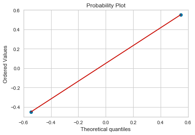

```python
#QQ plot
stats.probplot(y_rf_predictions - y_test, dist="norm", plot=plt)
plt.show()
```

## Clustering Validation

Clustering is one of the most useful tasks in data mining process for discovering groups and identifying interesting distributions and patterns in the underlying data. Clustering problem is about partitioning a given data set into groups (clusters) such that the data points in a cluster are more similar to each other than points in different clusters.

Cluster validation is concerned with the quality of clusters generated by an algorithm for clustering. Given the partitioning of a data set, it attempts to answer questions such as:

- Does the dataset show clustering tendency, i.e., distinguishing whether non-random structure actually exists in the data
- How pronounced is the cluster structure that has been identified
- How do clustering solutions from different algorithms compare
- How do clustering solutions for different parameters (e.g. the number of clusters) compare

### Clustering Validation Methodology

[figure not shown]

General approach for clustering model validation is:

1. Divide the data into two subset of almost similar size, dataset ‘A’ for training and dataset ‘B’ for validation
2. Apply clustering algorithm on training dataset ‘A’ to get ‘c’ clusters
3. Score records in dataset ‘B’ to clustering model derived from dataset ‘A’
4. Apply same clustering algorithm on validation dataset ‘B’ to get ‘c’ clusters
5. Map the ‘c’ cluster from (4) to ‘c’ cluster from (2) to find corresponding cluster
6. For every record in dataset ‘B’, compare the two cluster label from step (3) and (5)

Models with high agreement between the two clusters for observations in ‘B’ is preferred. Adjusted Rand Index (ARI) (or any similar metric such as Rand Index, Meila’s VI, etc.) is used to calculate the agreement between two cluster sets. ARI value ranges between [-1, +1], with a high value denoting greater agreement:

- 1 stands for perfect match while 0 stands for random labeling
- Negative ARI denotes the agreement is less than what is expected from a random result

Acceptable value of ARI is very subjective and depends on type and field of information. Typically, ARI value excess of 0.5 can be considered as good agreement.

High agreement indicates the ability of the clustering model to predict the clusters of another data set sampled from the same source. Hence proving **Population is stable and model is generalized**.

### Cluster Tendency and Types of Validation

**Cluster Tendency**

Clustering tendency assessment determines whether a given dataset contains meaningful clusters (i.e., non-random structure). This should be performed as an initial test, before attempting clustering. One way to do this is to compare the data against random data. Hopkins statistic and VAT: Visual Assessment of cluster Tendency are common ways to assess cluster tendency.

**Types of Cluster Validation**

Based on the numerical measures that are applied to judge various aspects of cluster validity, cluster validation can be classified into the following four types:

- **Relative clustering validation**, which evaluates the clustering structure by varying different parameter values for the same algorithm (example: varying the number of clusters k). It is generally used for determining the optimal number of clusters. These indices often attempt to exploit redundancy in the data. Most often internal validation measures and external validation measures are used for relative clustering validation.
- **Internal clustering validation**, which use the internal information of the clustering process to evaluate the goodness of a clustering structure without reference to external information. It can be also used for estimating the number of clusters and the appropriate clustering algorithm without any external data.
- **External clustering validation**, which consists of comparing the results of a cluster analysis to an externally known result, such as externally provided class labels. Since we know the “true” cluster number in advance, this approach is mainly used for selecting the right clustering algorithm for a specific dataset.
- **Clustering stability validation**, which is a special version of internal validation. It evaluates the consistency of a clustering result by comparing it with the clusters obtained after each column is removed, one at a time. This is to sense the stability of the algorithm against variations in the data.

### Internal Cluster Validation

Internal validation measures reflect often the compactness, the connectedness and separation of the cluster partitions. That is, the average distance within cluster should be as small as possible; and the average distance between clusters should be as large as possible.

- Compactness measures evaluate how close the objects within the same cluster are. A lower within-cluster variation is an indicator of a good compactness (i.e., a good clustering). The different indices for evaluating the compactness of clusters are based on distance measures such as the within cluster average distances between observations.
- Separation measures determine how well-separated a cluster is from other clusters. The indices used as separation measures include distances between cluster centers and the pairwise minimum distances between objects in different clusters.
- Connectivity corresponds to what extent items are placed in the same cluster as their nearest neighbors in the data space. The connectivity has a value between [0, ∞) and should be minimized.

Few common internal clustering validation measures are:

| **Validation Measure** | **Description** |
| --- | --- |
| **Silhouette Index/Width** | Silhouette analysis measures how well an observation is clustered and it estimates the average distance between clusters. The silhouette plot displays a measure of how close each point in one cluster … |
| **Dunn Index** | The Dunn Index measures the ratio between the smallest cluster distance and the largest intra-cluster distance in a partitioning. The Dunn Index is limited to the interval [0, ∞) and should be maximiz… |
| **BIC Index** | The Bayesian information criterion (BIC) is devised to avoid overfitting. The BIC index takes into account both fit of the model to the data and the complexity of the model. A model that has a smaller… |
| **Davies-Bouldin Index** | This index aims to identify sets of clusters that are compact and well separated. Smaller value of DB indicates a “better” clustering solution. |

*Table 1: Common internal clustering validation measures*

Apart from these common measures, there are several other internal validation measures. A few examples include:

- Ball-Hall index
- Banfeld-Raftery index
- C index
- Calinski-Harabasz index
- Det Ratio index
- Baker-Hubert Gamma index
- GDI index
- G plus index
- Ksq DetW index
- Log Det Ratio index
- Log SS Ratio index
- McClain-Rao index
- PBM index
- Point-Biserial index
- Ratkowsky-Lance index
- Ray-Turi index
- Scott-Symons index
- SD index
- S Dbw index
- Tau index
- Trace W index
- Trace WiB index
- Wemmert-Gan – carski index
- Xie-Beni index

```python
clust_df = pd.read_csv("clustering.csv")
clust_df.head()
```

|  | principal component 1 | principal component 2 |
| --- | --- | --- |
| 0 | -2.649758 | -1.367236 |
| 1 | -2.371785 | 0.481255 |
| 2 | -1.542017 | -0.891844 |
| 3 | -2.802181 | -2.480306 |
| 4 | -0.399353 | -0.893956 |

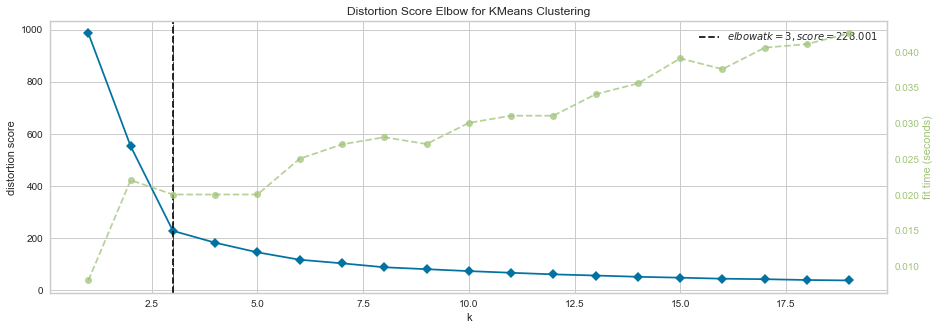

```python
## Compactness
plt.figure(figsize = (15,5))
plt.axvline(x=3, linewidth=1, color='red', linestyle = "--")
from yellowbrick.cluster import KElbowVisualizer
model = KMeans(random_state = 101)
visualizer = KElbowVisualizer(model, k=(1,20))
visualizer.fit(clust_df)
visualizer.poof()
```

In general, the cost function of clustering or the total Within Sum of Squares (WSS) variance is used as the y-axis of the elbow curve. Alternatively, the distortion score which computes the sum of squared distances from each point to its assigned center can also be used.

From the above figure, an elbow can be seen at k = 3. Hence, k=3 is used as the cut-off.

The green line in the figure indicates the time taken to compute the kMeans algorithm.

```
Automatically created module for IPython interactive environment
For n_clusters = 2 The average silhouette_score is : 0.4240396292301052
For n_clusters = 3 The average silhouette_score is : 0.5505735745091285
For n_clusters = 4 The average silhouette_score is : 0.47989248770742354
For n_clusters = 5 The average silhouette_score is : 0.4229475829242102
For n_clusters = 6 The average silhouette_score is : 0.39418641744003474
```

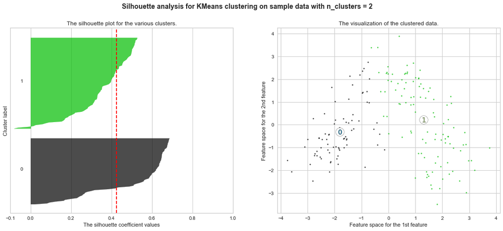

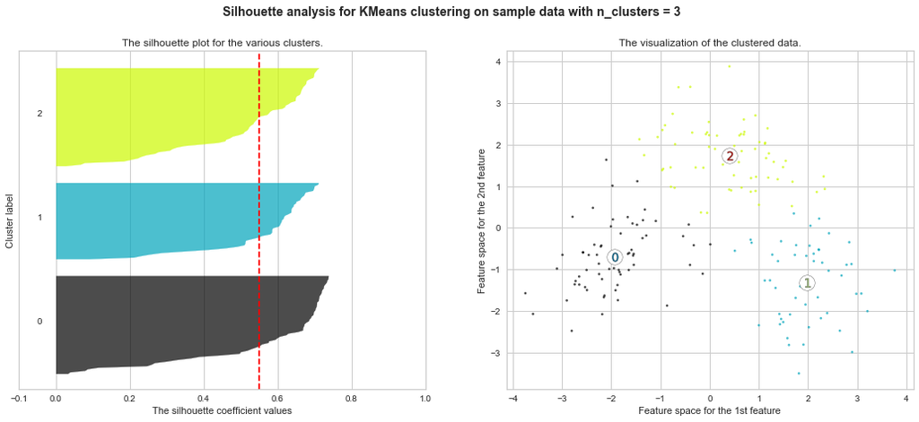

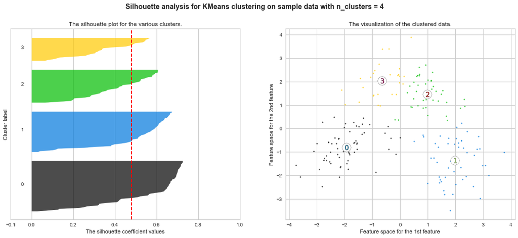

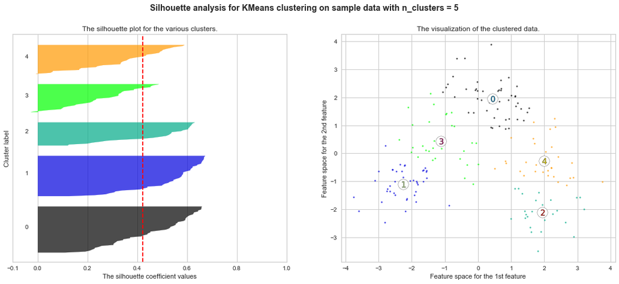

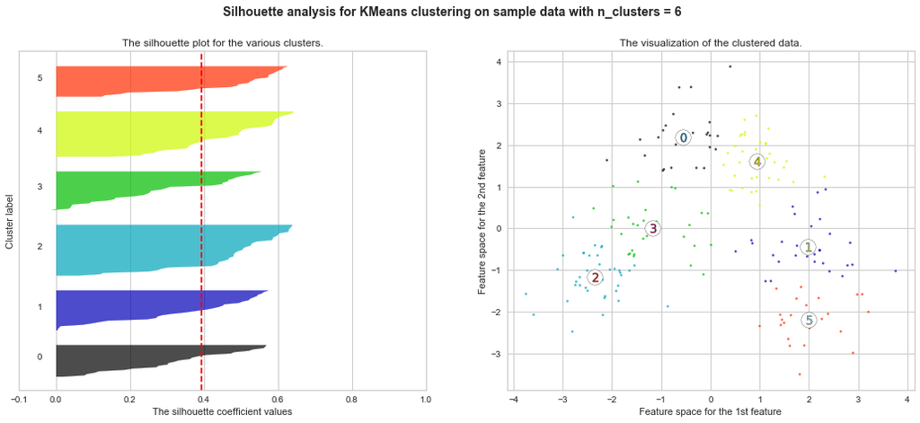

```python
## Silhouette width
principalDf = clust_df

from sklearn.datasets import make_blobs
from sklearn.cluster import KMeans
from sklearn.metrics import silhouette_samples, silhouette_score

import matplotlib.pyplot as plt
import matplotlib.cm as cm
import numpy as np

print(__doc__)

range_n_clusters = [2, 3, 4, 5, 6]

for n_clusters in range_n_clusters:
    # Create a subplot with 1 row and 2 columns
    fig, (ax1, ax2) = plt.subplots(1, 2)
    fig.set_size_inches(18, 7)

    # The 1st subplot is the silhouette plot
    # The silhouette coefficient can range from -1, 1 but in this example all
    # lie within [-0.1, 1]
    ax1.set_xlim([-0.1, 1])
    # The (n_clusters+1)*10 is for inserting blank space between silhouette
    # plots of individual clusters, to demarcate them clearly.
    ax1.set_ylim([0, len(principalDf) + (n_clusters + 1) * 10])

    # Initialize the clusterer with n_clusters value and a random generator
    # seed of 10 for reproducibility.
    clusterer = KMeans(n_clusters = n_clusters, random_state=101)
    cluster_labels = clusterer.fit_predict(principalDf)

    # The silhouette_score gives the average value for all the samples.
    # This gives a perspective into the density and separation of the formed
    # clusters
    silhouette_avg = silhouette_score(principalDf, cluster_labels)
    print("For n_clusters =", n_clusters,
          "The average silhouette_score is :", silhouette_avg)

    # Compute the silhouette scores for each sample
    sample_silhouette_values = silhouette_samples(principalDf, cluster_labels)

    y_lower = 10
    for i in range(n_clusters):
        # Aggregate the silhouette scores for samples belonging to
        # cluster i, and sort them
        ith_cluster_silhouette_values = \
            sample_silhouette_values[cluster_labels == i]

        ith_cluster_silhouette_values.sort()

        size_cluster_i = ith_cluster_silhouette_values.shape[0]
        y_upper = y_lower + size_cluster_i

        color = cm.nipy_spectral(float(i) / n_clusters)
        ax1.fill_betweenx(np.arange(y_lower, y_upper),
                          0, ith_cluster_silhouette_values,
                          facecolor=color, edgecolor=color, alpha=0.7)

        # Label the silhouette plots with their cluster numbers at the middle
        ax1.text(-0.05, y_lower + 0.5 * size_cluster_i, str(i))

        # Compute the new y_lower for next plot
        y_lower = y_upper + 10  # 10 for the 0 samples

    ax1.set_title("The silhouette plot for the various clusters.")
    ax1.set_xlabel("The silhouette coefficient values")
    ax1.set_ylabel("Cluster label")

    # The vertical line for average silhouette score of all the values
    ax1.axvline(x=silhouette_avg, color="red", linestyle="--")

    ax1.set_yticks([])  # Clear the yaxis labels / ticks
    ax1.set_xticks([-0.1, 0, 0.2, 0.4, 0.6, 0.8, 1])

    # 2nd Plot showing the actual clusters formed
    colors = cm.nipy_spectral(cluster_labels.astype(float) / n_clusters)
    ax2.scatter(principalDf.iloc[:, 0], principalDf.iloc[:, 1], marker='.', s=30, lw=0, alpha=0.7,
                c=colors, edgecolor='k')

    # Labeling the clusters
    centers = clusterer.cluster_centers_
    # Draw white circles at cluster centers
    ax2.scatter(centers[:, 0], centers[:, 1], marker='o',
                c="white", alpha=1, s=300, edgecolor='k')

    for i, c in enumerate(centers):
        ax2.scatter(c[0], c[1], marker='$%d$' % i, alpha=1,
                    s=100, edgecolor='k')

    ax2.set_title("The visualization of the clustered data.")
    ax2.set_xlabel("Feature space for the 1st feature")
    ax2.set_ylabel("Feature space for the 2nd feature")

    plt.suptitle(("Silhouette analysis for KMeans clustering on sample data "
                  "with n_clusters = %d" % n_clusters),
                 fontsize=14, fontweight='bold')

plt.show()
```

The average silhouette_score for K=3 is 0.55 is the closest score to 1 among other values of K which means that the assignment of data points to the respective clusters is more appropriate when the number of clusters are 3. Hence, 3 clusters shall be created using K-Means in the following step.

```python
model = KMeans(3, random_state = 101)
model.fit(principalDf)
labels = model.labels_
```

```python
## DB index
print("Db index:",davies_bouldin_score(clust_df, labels)  )
```

```
Db index: 0.6013456830531186
```

### External Cluster Validation

In external validation, clustering results are validated based on data that was not used for clustering, such as known class labels and external benchmarks. Such benchmarks consist of a set of pre-classified items, and these sets are often created by (expert) humans. Thus, the benchmark sets can be thought of as a gold standard for evaluation. These types of evaluation methods measure how close the clustering is to the predetermined benchmark classes.

Some of the external clustering validation measures are:

| **Validation Measure** | **Description** |
| --- | --- |
| **Purity** | Purity is a measure of the extent to which clusters contain a single class. It is a fraction of the overall cluster size and the largest class of objects assigned to that cluster represents. The overa… |
| **Entropy** | Entropy measures the purity of the clusters class labels. Thus, if all clusters consist of objects with only a single class label, the entropy is 0. However, as the class labels of objects in a cluste… |
| **F – Measure** | F-measure combines the precision and recall concepts. **Precision = TP / (TP+FP) (1)** **Recall = TP / (TP+FN) (2)** **F-measure = (2*R*P) / (R+P) (3)** The F-Measure values are within the interval [0… |
| **Rand Index** | The Rand index computes how similar the clusters (returned by the clustering algorithm) are to the benchmark classifications. Rand index is a measure of the percentage of correct decisions made by the… |
| **Jaccard Index** | The Jaccard index is used to quantify the similarity between two datasets. It is the number of unique elements common to both sets divided by the total number of unique elements in both sets. The Jacc… |

*Table 2: Common external clustering validation measures*

Abbreviations used:

- TP : True Positive
- TN : True Negative
- FP : False Positive
- FN : False Negative
- P : Precision
- R : Recall

Apart from these common measures, there are several other external validation measures. A few examples include:

- Mutual Information
- Czekanowski-Dice index
- Folkes-Mallows index
- Hubert $Γ$ index
- Kulczynski index
- McNemar index
- Phi index
- Rand index
- Rogers-Tanimoto index
- Russel-Rao index
- Sokal-Sneath indices

### Clustering Stability Validation

The stability measures compare the results from clustering based on the full data to clustering based on removing each column, one at a time. This is because of the assumption that samples in the same cluster should possess similar pattern vectors for additional features that were not considered in the clustering process. These measures work especially well if the data are highly correlated, which is often the case in real world data. In all cases, the average is taken over all the deleted columns, and all measures should be minimized.

Few of the clustering stability validation measures are:

| **Validation Measure** | **Description** |
| --- | --- |
| **Average Proportion of Non-overlap (APN)** | The APN measures the average proportion of observations not placed in the same cluster by clustering based on the full data and clustering based on the data with a single column removed. The APN is in… |
| **Average Distance (AD)** | The AD measure computes the average distance between observations placed in the same cluster by clustering based on the full data and clustering based on the data with a single column removed. The AD … |
| **Average Distance between Means (ADM)** | The ADM measure computes the average distance between cluster centers for observations placed in the same cluster by clustering based on the full data and clustering based on the data with a single co… |
| **Figure of Merit (FOM)** | The FOM measures the average intra-cluster variance of the observations in the deleted column, where the clustering is based on the remaining (undeleted) samples. This estimates the mean error using p… |

*Table 3: Common clustering stability validation measure*

## Classification Validation

Classification is the process of identifying to which of a set of categories (sub-populations) a new observation belongs, on the basis of a training set of data containing observations whose category membership is known. Logistic Regression, LDA (Linear Discriminant Analysis) and Decision Trees are few common classification methods.

Validation in classification is concerned with the **quality of fit** and **generalizability** of the model. Since most of the classification algorithm have an innate tendency to overfit on training dataset, validation in classification is critically important.

Main dimensions of the model’s performance are:

- **Discrimination** – Discrimination refers to the ability of the model to distinguish correctly the classes of outcomes. In other words, it is a measure of the ability of the model to separate subjects with different responses. Perfect discrimination would result in non-overlapping distributions of predicted probabilities for the sub-groups (classes). Sensitivity, Specificity, c- Statistic (AUC – ROC) are few example of discrimination measures.
- **Calibration –** Calibration is a measure of how close the predicted probabilities are to the observed rate of the positive outcome for any given configuration of the independent variables of the model. Hosmer and Lemeshow χ<sup>2</sup> GoF test and bias are few example of calibration measures.

A predictive model cannot have both a perfect calibration and a perfect discrimination. A model that maximizes discrimination does so at the expense of calibration, and vice versa. As a consequence, a good model should balance between these two dimensions of performance in order to find the best trade-off.

It is generally believed that discrimination is more important than calibration. If discrimination is good, the predictive model can in some way be recalibrated without sacrificing much of discrimination. If the predictive model has poor discrimination, no adjustment can correct the model. As a general rule, whenever the model is needed only to rank likely outcomes and not predict absolute probabilities, then calibration is much less important than discrimination. Although, it must be noted that the importance of calibration relative to discrimination is strongly influenced by the field of analysis and the intended application.

### Classification Validation Methodology

[figure not shown]

*Fig 10: The methodology of classification validation*

General approach for classification model validation is:

1. Randomly divide the dataset into training and validation samples. Holdout, bootstrapping and K-fold cross validation are few common techniques used for data splitting
2. Apply classification algorithm on the training dataset
3. Use the fitted model to estimate the probability of a positive outcome for each of the records in both the training and the validation samples. As a consequence, for each record, following values are known:
- the configuration of the covariates X
- the observed outcome Y
- the predicted probability of a positive outcome P(Y = 1|X)
4. For both the training and the validation samples, different validation measures are computed and compared
5. The above steps (1-4) are repeated multiple times to increase randomness in the two datasets

The measures computed for training samples should be in agreement with the acceptable values for the respective measure.

High agreement between measures computed on training and validation dataset indicates the ability of the model to predict on another data set sampled from the same source. Hence proving **model is not overfitting and is generalized**.

### Classification Validation Measures

Few common classification validation measures are:

| **Validation Measure** | **Description** |
| --- | --- |
| **Model’s significance** | For each parameter, test the null hypothesis that the coefficient is equal to zero (no effect on outcome). A low p-value (< 0.05) indicates that null hypothesis can be rejected. Typically, coefficient… |
| **Stability of the parameter’s estimates** | The parameter estimates for different randomly generated training sets should be stable (low varying). Large variability indicates the presence of some degree of overfitting. |
| **c – Statistic** | Computed from the number of times that a subject with a positive outcome has a higher event probability than a subject with a negative outcome (concordant pair). This is a measure of discrimination. *… |
| **Hosmer and Lemeshow χ<sup>2</sup> goodness of fit test** | The test assesses whether or not the observed event rates match expected event rates in subgroups of the model population. The Hosmer–Lemeshow test specifically identifies subgroups as the deciles of … |
| **Accuracy** | **Accuracy = (TP+TN) / (TP+TN+FP+FN)** |
| **Sensitivity/Recall/TPR &** **Specificity/TNR** | **Sensitivity = TP / (TP+FN) (8)** **Specificity = TN / (TN+FP) (9)** |
| **F – measure** | F-measure combines the precision and recall concepts. **Precision = TP / (TP+FP) (10)** **Recall = TP / (TP+FN) (11)** **F – measure = (2*R*P) / (R+P) (12)** The F-Measure values are within the interv… |
| **Lift** | Lift is a measure of the effectiveness of a predictive model, calculated as the ratio between the results obtained with and without the predictive model. |
| **Kolmogorov–Smirnov test** | K-S test is a measure of the degree of separation between the sub-populations (classes). |
| **Area under the ROC curve (AUC – ROC)** | A receiver operating characteristic curve, i.e. ROC curve, is a graphical plot that illustrates the diagnostic ability of a binary classifier system as its discrimination threshold is varied. The ROC … |

*Table 4: Common classification validation measures*

Abbreviations used:

- TP : True Positive
- TN : True Negative
- FP : False Positive
- FN : False Negative
- P : Precision
- R : Recall

```python
classification_df = pd.read_csv("classification.csv")

#Splitting the dataset
X = classification_df.loc[:, classification_df.columns.isin(["Survived"])]
y = classification_df["Survived"]
X_train, X_test, y_train, y_test = train_test_split(X, y, test_size=0.25, random_state=101)

# Random Forest
from sklearn.ensemble import RandomForestClassifier
random_forest = RandomForestClassifier(n_estimators=100)
random_forest.fit(X_train, y_train)

# Testing the model
y_pred = random_forest.predict(X_test)
```

```python
# Accuracy
random_forest.score(X_train, y_train)
acc_random_forest = round(random_forest.score(X_train, y_train) * 100, 2)
print("Accuracy: ",acc_random_forest)
```

```
Accuracy:  100.0
```

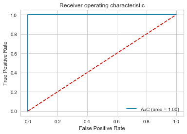

```python
# AuRoC
roc_curve(y_test, y_pred)
```

```python
## F1 score
print("F1 Score: ",f1_score(y_test, y_pred))
```

```
F1 Score:  1.0
```

```python
## Log loss score
print("Logarithmic-Loss Score: ",log_loss(y_test, y_pred))
```

```
Logarithmic-Loss Score:  9.992007221626413e-16
```

```python
## Precision
print("Precision : ",precision_score(y_test, y_pred))
```

```
Precision :  1.0
```

```python
# Recall
print("Recall : ",recall_score(y_test, y_pred))
```

```
Recall :  1.0
```

```python
#Kolmogorov–Smirnov test
from scipy.stats import kstest
kstest(y_test, "norm")
```

```
KstestResult(statistic=0.5, pvalue=4.4609932471054735e-52)
```

```
Confusion matrix, without normalization
[[127   0]
 [  0  96]]
```

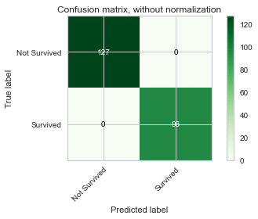

```python
## Confusion Matrix
class_names = ["Not Survived", "Survived"]
np.set_printoptions(precision=2)

plot_confusion_matrix(y_test, y_pred, classes=class_names,
                      title='Confusion matrix, without normalization')
```

The other validation techniques cannot be performed directly in python and are not included in the notebook.